# The reduction in weekly working hours in Europe

Looking at the development between 1996 and 2006

Mehul Sachdeva

2019-06-08

## Summary

The **International Labour Organization (ILO)** has many [data sets](http://www.ilo.org/global/statistics-and-databases/lang--en/index.htm) on working conditions. For example, one can look at how weekly working hours have been decreasing in many countries of the world, while monetary compensation has risen. In this report, *the reduction in weekly working hours* in European countries is analysed, and a comparison between 1996 and 2006 is made. All analysed countries have seen a decrease in weekly working hours since 1996 – some more than others.

## Preparations

```r
library(dplyr)
library(ggplot2)
library(forcats)
```

## Analysis

### Data

The herein used data can be found in the statistics database of the ILO. For the purpose of this course, it has been slightly preprocessed.

```r
load(url("http://s3.amazonaws.com/assets.datacamp.com/production/course_5807/datasets/ilo_data.RData"))
```

The loaded data contains 380 rows.

```r
ilo_data %>%
  group_by(year) %>%
  summarise(mean_hourly_compensation = mean(hourly_compensation), mean_working_hours = mean(working_hours)) %>%
  knitr::kable()
```

| year | mean_hourly_compensation | mean_working_hours |
| --- | --- | --- |
| 1980 | 9.267500 | 33.98103 |
| 1981 | 8.692500 | 33.61923 |
| 1982 | 8.355000 | 33.47409 |
| 1983 | 7.809091 | 33.86589 |
| 1984 | 7.543636 | 33.71051 |
| 1985 | 7.786364 | 33.73358 |
| 1986 | 9.700000 | 33.97494 |
| 1987 | 12.146923 | 33.58138 |
| 1988 | 13.199231 | 33.66441 |
| 1989 | 13.136154 | 33.53312 |
| 1990 | 16.016923 | 33.41275 |
| 1991 | 16.548461 | 33.04459 |
| 1992 | 17.807692 | 32.82919 |
| 1993 | 16.502857 | 32.48288 |
| 1994 | 16.543333 | 32.92779 |
| 1995 | 18.420589 | 33.25749 |
| 1996 | 18.528824 | 33.15975 |
| 1997 | 16.910000 | 33.10471 |
| 1998 | 16.999412 | 32.94524 |
| 1999 | 16.865882 | 32.75325 |
| 2000 | 15.390000 | 32.45301 |
| 2001 | 15.495882 | 32.10170 |
| 2002 | 17.186471 | 31.89615 |
| 2003 | 20.969412 | 31.77210 |
| 2004 | 23.687059 | 31.82506 |
| 2005 | 24.501176 | 31.82508 |
| 2006 | 25.446470 | 31.78460 |

As can be seen from the above table, the average weekly working hours of European countries have been descreasing since 1980.

### Preprocessing

The data is now filtered so it only contains the years 1996 and 2006 a good time range for comparison.

```r
ilo_data <- ilo_data %>%
  filter(year == 1996 | year == 2006)

ilo_data <- ilo_data %>%
  arrange(year) %>%
  mutate(country = fct_reorder(country, working_hours, last))
```

### Results

In the following, a plot that shows the reduction of weekly working hours from 1996 to 2006 in each country is produced.

First, a custom theme is defined.

Then, the plot is produced.

```r
ilo_data_median <- ilo_data %>%
  group_by(country) %>%
  summarise(median_working_hours = median(working_hours))

glimpse(ilo_data_median)
```

```
## Observations: 17
## Variables: 2
## $ country              <fct> Netherlands, Norway, Germany, France, Bel...
## $ median_working_hours <dbl> 27.03846, 27.79615, 28.37019, 30.99135, 3...
```

```r
theme_custom <- function() {
  theme(text = element_text(family = "mono", size = 15),
        plot.margin = unit(c(10,10,10,10),units = "mm"))
}
```

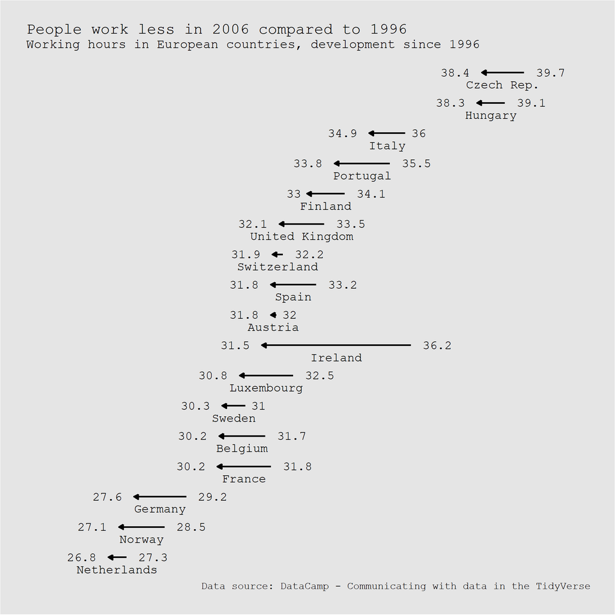

```r
ggplot(ilo_data) +
  geom_path(aes(x = working_hours,y = country), arrow = arrow(length = unit(2,units = "mm"),type = "closed"), size = 1) +
  geom_text(aes(x = working_hours,y = country, label = round(working_hours,1), hjust = ifelse(year == 2006,1.4,-0.4)), family = "mono", size = 5) +
  geom_text(data = ilo_data_median, aes(x = median_working_hours,y = country, label = country), nudge_y = -0.4, family = "mono", size = 5) +
  labs(title = "People work less in 2006 compared to 1996",
        subtitle = "Working hours in European countries, development since 1996",
       caption = "Data source: DataCamp - Communicating with data in the TidyVerse") +
    theme(axis.text = element_blank(), axis.ticks = element_blank(), axis.title = element_blank(), panel.grid = element_blank(),
          panel.background = element_rect(fill = "gray90"), plot.background = element_rect(fill = "gray90")) +
  theme_custom() +
  coord_cartesian(xlim = c(25,41))
```

#### An interesting correlation

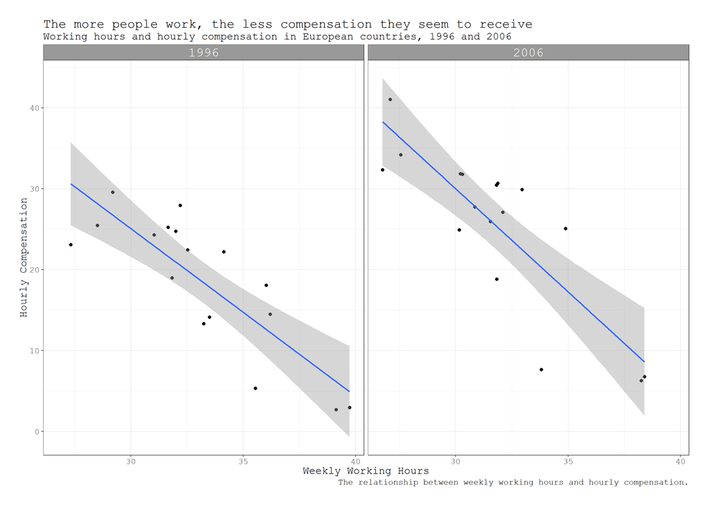

```r
ggplot(ilo_data) +
  geom_point(aes(x = working_hours, y = hourly_compensation), size = 2) +
  geom_smooth(aes(x = working_hours, y = hourly_compensation),method = "lm") +
  facet_grid(.~year) +
  labs(title = "The more people work, the less compensation they seem to receive",
      subtitle = "Working hours and hourly compensation in European countries, 1996 and 2006",
      caption = "The relationship between weekly working hours and hourly compensation.",
      x = "Weekly Working Hours",
      y = "Hourly Compensation") +
  theme_bw() +
  theme_custom() +
  theme(strip.background = element_rect(fill = "gray60"), strip.text = element_text(colour = "white",size = 18))
```

As you can see, there’s also an interesting relationship. The more people work, the less compensation they seem to receive, which seems kind of unfair. This is quite possibly related to other proxy variables like overall economic stability and performance of a country.